# PopHIVE Standard Dataset Validation Report

PopHIVE / Ingest

2026-08-14

```r
data_path <- proj_path(params$data_file)
stopifnot("data_file does not exist" = file.exists(data_path))

# Read with geography + time forced to character so FIPS leading zeros survive.
dat <- vroom(
  data_path, show_col_types = FALSE,
  col_types = cols(geography = "c", time = "c")
)
roles <- classify_columns(dat)

# Each value measure's matching suppression-flag column(s), resolved once here
# instead of re-running the token matching every time it's needed below
# (suppression checks, and the flag lookups in sections 4 and 5).
measure_flags <- setNames(
  lapply(roles$values, flags_for_measure, flag_cols = roles$flags),
  roles$values
)

# Load measure_info.json for short-name lookups and measure_type (gracefully absent)
measure_info <- NULL
mi_path <- file.path(dirname(dirname(data_path)), "measure_info.json")
if (file.exists(mi_path)) {
  measure_info <- tryCatch(jsonlite::read_json(mi_path), error = function(e) NULL)
}
short_name_fn <- function(v) {
  if (!is.null(measure_info) && !is.null(measure_info[[v]]) &&
      !is.null(measure_info[[v]]$short_name))
    measure_info[[v]]$short_name else v
}
measure_label <- function(vars) {
  vapply(vars, function(v) {
    sn <- short_name_fn(v)
    if (identical(sn, v)) v else sprintf("%s (%s)", sn, v)
  }, character(1), USE.NAMES = FALSE)
}

# ---------------------------------------------------------------------------
# Previous version of the SAME file: an explicit old_data_file, else the
# previous git version. Loaded once here so both the category comparison
# (section 2) and the value/trend comparison (section 7) can reuse it.
# ---------------------------------------------------------------------------
old_path  <- proj_path(params$old_data_file)
old_label <- NULL
old       <- NULL
old_roles <- NULL

if (nzchar(old_path) && file.exists(old_path)) {
  old_label <- sprintf("`%s`", params$old_data_file)
} else if (isTRUE(params$git_compare)) {
  git_info <- extract_git_version(data_path, params$git_ref)
  if (!is.null(git_info)) {
    old_path  <- git_info$path
    old_label <- paste0("its previous **git** version: ", git_info$meta)
  }
}
if (!is.null(old_label) && file.exists(old_path)) {
  old <- vroom(old_path, show_col_types = FALSE,
               col_types = cols(geography = "c", time = "c"))
  old_roles <- classify_columns(old)
}
```

# 1. Overview

```r
cat(sprintf("- **File:** `%s`\n", params$data_file))
```

- **File:** `data/cosmos_gas/standard/data.csv.gz`

```r
cat(sprintf("- **Rows:** %s &nbsp;&nbsp; **Columns:** %s\n",
            format(nrow(dat), big.mark = ","), ncol(dat)))
```

- **Rows:** 13,104 **Columns:** 8

```r
cat(sprintf("- **ID columns:** %s\n", paste(roles$id, collapse = ", ")))
```

- **ID columns:** geography, time

```r
cat(sprintf("- **Demographic columns:** %s\n",
            if (length(roles$demo)) paste(roles$demo, collapse = ", ") else "_none_"))
```

- **Demographic columns:** age

```r
cat(sprintf("- **Value measures (%d):** %s\n", length(roles$values),
            paste(roles$values, collapse = ", ")))
```

- **Value measures (3):** epic_n_strep_throat, epic_pct_strep_throat, epic_n_patients

```r
# Every value measure should have at least one matching suppression flag.
measure_with_flag <- roles$values[lengths(measure_flags[roles$values]) > 0]

if (length(roles$flags) == 0) {
  cat("- **Suppression flag columns:** none present (not applicable)\n")
} else {
  miss <- setdiff(roles$values, measure_with_flag)
  cat(sprintf("- **Suppression flag columns:** %d/%d value measures have a matching flag%s\n",
              length(measure_with_flag), length(roles$values),
              if (length(miss))
                sprintf(" — **no flag matched for:** %s", paste(miss, collapse = ", "))
              else " (all matched)"))
}
```

- **Suppression flag columns:** 3/3 value measures have a matching flag (all matched)

```r
# Geographic coverage
gl <- nchar(dat$geography)
geo_levels <- c("national (00)" = sum(dat$geography == "00"),
                "state (2-digit)" = sum(gl == 2 & dat$geography != "00"),
                "county (5-digit)" = sum(gl == 5))
geo_levels <- geo_levels[geo_levels > 0]
cat(sprintf("- **Geographic coverage:** %s\n",
            paste(sprintf("%s rows %s", format(geo_levels, big.mark=","), names(geo_levels)),
                  collapse = "; ")))
```

- **Geographic coverage:** 252 rows national (00); 12,852 rows state (2-digit)

```r
cat(sprintf("- **Time range:** %s to %s (%d distinct periods)\n",
            min(dat$time), max(dat$time), length(unique(dat$time))))
```

- **Time range:** 2017-03-31 to 2025-12-31 (36 distinct periods)

## Format checks

```r
# Basic standard-format sanity checks on the id columns.
bad_geo <- dat$geography[!grepl("^[0-9]{2}$|^[0-9]{5}$", dat$geography)]
cat(sprintf("- Geography codes are valid FIPS (2- or 5-digit): %s\n",
            if (length(bad_geo) == 0) "PASS" else
              sprintf("FAIL (%d bad, e.g. %s)", length(bad_geo),
                      paste(head(unique(bad_geo), 5), collapse=", "))))
```

- Geography codes are valid FIPS (2- or 5-digit): PASS

```r
parsed <- suppressWarnings(as.Date(dat$time))
cat(sprintf("- Time parses as YYYY-mm-dd date: %s\n",
            if (!any(is.na(parsed))) "PASS" else
              sprintf("FAIL (%d unparseable)", sum(is.na(parsed)))))
```

- Time parses as YYYY-mm-dd date: PASS

```r
dups <- dat %>% count(across(all_of(c(roles$id, roles$demo)))) %>% filter(n > 1)
cat(sprintf("- Unique rows per geography/time/demographics: %s\n",
            if (nrow(dups) == 0) "PASS" else sprintf("FAIL (%d duplicate keys)", nrow(dups))))
```

- Unique rows per geography/time/demographics: PASS

```r
# --- Time contiguity: are the distinct periods in the file evenly spaced with
# no missing week/month/year, and (for weekly data) does each period end on a
# Saturday, matching the Sunday-Saturday epiweek convention? ---
time_dates <- sort(unique(parsed[!is.na(parsed)]))
if (length(time_dates) < 2) {
  cat("- Time contiguity: only one distinct time period, skipping\n")
} else {
  gaps <- as.numeric(diff(time_dates))
  mode_gap <- as.numeric(names(sort(table(gaps), decreasing = TRUE))[1])
  resolution <- if (mode_gap == 7) "weekly" else
    if (mode_gap %in% 28:31) "monthly" else
    if (mode_gap %in% 365:366) "annual" else "irregular"

  if (resolution == "weekly") {
    bad_gaps <- time_dates[which(gaps != 7) + 1]
    cat(sprintf("- Weekly dates contiguous (7-day spacing, no gaps): %s\n",
                if (length(bad_gaps) == 0) "PASS" else
                  sprintf("FAIL (%d gap(s), e.g. before %s)", length(bad_gaps),
                          paste(head(bad_gaps, 5), collapse = ", "))))
    # %u: ISO weekday as 1 (Mon) - 7 (Sun); Saturday == 6, i.e. a Sun-Sat week.
    wday_bad <- time_dates[format(time_dates, "%u") != "6"]
    cat(sprintf("- Weekly periods end on Saturday (Sun-Sat week): %s\n",
                if (length(wday_bad) == 0) "PASS" else
                  sprintf("FAIL (%d date(s) not a Saturday, e.g. %s)", length(wday_bad),
                          paste(head(wday_bad, 5), collapse = ", "))))
  } else if (resolution == "monthly") {
    ym <- format(time_dates, "%Y-%m")
    expected_months <- format(seq(time_dates[1], time_dates[length(time_dates)], by = "month"), "%Y-%m")
    missing_months <- setdiff(expected_months, ym)
    cat(sprintf("- Monthly dates contiguous (no missing months): %s\n",
                if (length(missing_months) == 0) "PASS" else
                  sprintf("FAIL (%d missing month(s), e.g. %s)", length(missing_months),
                          paste(head(missing_months, 5), collapse = ", "))))
  } else if (resolution == "annual") {
    yrs <- as.numeric(format(time_dates, "%Y"))
    missing_years <- setdiff(seq(min(yrs), max(yrs)), yrs)
    cat(sprintf("- Annual dates contiguous (no missing years): %s\n",
                if (length(missing_years) == 0) "PASS" else
                  sprintf("FAIL (%d missing year(s): %s)", length(missing_years),
                          paste(missing_years, collapse = ", "))))
  } else {
    cat(sprintf("- Time contiguity: irregular spacing detected (most common gap = %d days); skipping automated contiguity check\n",
                mode_gap))
  }
}
```

- Time contiguity: irregular spacing detected (most common gap = 92 days); skipping automated contiguity check

# 2. Demographic categories

```r
if (length(roles$demo) == 0) {
  cat("_No demographic columns in this dataset._\n")
} else {
  cat_tab <- lapply(roles$demo, function(col) {
    lv <- sort(unique(as.character(dat[[col]])))
    data.frame(variable = col, n_categories = length(lv),
               categories = paste(lv, collapse = " | "),
               stringsAsFactors = FALSE)
  })
  kable(bind_rows(cat_tab), caption = "Demographic categories in the new dataset")
}
```

Demographic categories in the new dataset

| variable | n_categories | categories |
| --- | --- | --- |
| age | 7 | <1 Years \| 1-4 Years \| 18-49 Years \| 5-17 Years \| 50-64 Years \| 65+ Years \| Total |

```r
if (!is.null(old)) {
  cat("## Comparison with previous version\n\n")
  cat(sprintf("Comparing the current file against %s.\n\n", old_label))

  # --- did the data change at all? (signed change new-old, then the old total) ---
  sgn <- function(x) paste0(if (x > 0) "+" else "", format(x, big.mark = ","))
  cat(sprintf("- **Dimensions:** %s rows / %s cols vs previous (previous had %s rows / %d cols)%s\n\n",
              sgn(nrow(dat) - nrow(old)), sgn(ncol(dat) - ncol(old)),
              format(nrow(old), big.mark = ","), ncol(old),
              if (nrow(dat) == nrow(old) && identical(sort(names(dat)), sort(names(old))))
                " — same shape & columns" else " — **changed**"))

  # --- demographic category comparison ---
  shared_demo <- intersect(roles$demo, old_roles$demo)
  cmp <- lapply(shared_demo, function(col) {
    new_lv <- sort(unique(as.character(dat[[col]])))
    old_lv <- sort(unique(as.character(old[[col]])))
    added   <- setdiff(new_lv, old_lv)
    removed <- setdiff(old_lv, new_lv)
    data.frame(
      variable = col,
      n_new = length(new_lv), n_old = length(old_lv),
      added   = if (length(added))   paste(added, collapse = " | ")   else "-",
      removed = if (length(removed)) paste(removed, collapse = " | ") else "-",
      match = if (!length(added) && !length(removed)) "OK" else "DIFF",
      stringsAsFactors = FALSE
    )
  })
  if (length(cmp))
    print(kable(bind_rows(cmp),
                caption = "Category changes vs. previous version (added/removed levels)"))

  only_new_demo <- setdiff(roles$demo, old_roles$demo)
  only_old_demo <- setdiff(old_roles$demo, roles$demo)
  if (length(only_new_demo))
    cat(sprintf("\n- **Demographic columns only in NEW:** %s\n", paste(only_new_demo, collapse=", ")))
  if (length(only_old_demo))
    cat(sprintf("\n- **Demographic columns only in OLD:** %s\n", paste(only_old_demo, collapse=", ")))

  # --- measure (value-column) comparison ---
  added_m   <- setdiff(roles$values, old_roles$values)
  removed_m <- setdiff(old_roles$values, roles$values)
  cat("\n\n**Value measures:** ")
  cat(sprintf("%d new, %d old. ", length(added_m), length(old_roles$values)))
  cat(if (!length(added_m) && !length(removed_m)) "Identical set.\n" else
      sprintf("Added: %s. Removed: %s.\n",
              if (length(added_m)) paste(added_m, collapse=", ") else "none",
              if (length(removed_m)) paste(removed_m, collapse=", ") else "none"))
} else if (nzchar(proj_path(params$old_data_file))) {
  cat("_`old_data_file` was supplied but could not be found, skipping category comparison._\n")
} else if (isTRUE(params$git_compare)) {
  cat("_No `old_data_file` supplied and no distinct prior version of this file was found in git history (untracked, only one commit, or git unavailable), skipping comparison._\n")
} else {
  cat("_No previous version supplied and git comparison disabled, skipping category comparison._\n")
}
```

## Comparison with previous version

Comparing the current file against its previous **git** version: 681eb504 (2026-08-04) — standardize cosmos_gas to PopHIVE wide format.

- **Dimensions:** 0 rows / -1 cols vs previous (previous had 13,104 rows / 9 cols) — **changed**

Category changes vs. previous version (added/removed levels)

| variable | n_new | n_old | added | removed | match |
| --- | --- | --- | --- | --- | --- |
| age | 7 | 7 | - | - | OK |

**Value measures:** 0 new, 3 old. Identical set.

# 3. Missing values & suppression imputation checks

```r
na_tab <- data.frame(
  column = names(dat),
  n_missing = vapply(dat, function(x) sum(is.na(x)), integer(1)),
  stringsAsFactors = FALSE
)
na_tab$pct_missing <- fmt_pct(na_tab$n_missing / nrow(dat))
na_with <- na_tab[na_tab$n_missing > 0, ]
if (nrow(na_with) == 0) {
  cat("**No NA values found in any column.**\n\n")
} else {
  kable(na_with[order(-na_with$n_missing), ], row.names = FALSE,
        caption = "Columns containing NA values")
}
```

```
## **No NA values found in any column.**
```

```r
TOL <- 1e-6

# Authoritative denominator: parse "computed as A / B * 100" out of
# measure_info.json's long_description, when the source documents it that way.
formula_denominator <- function(v) {
  ld <- if (!is.null(measure_info) && !is.null(measure_info[[v]]))
    measure_info[[v]]$long_description else NULL
  if (is.null(ld)) return(NA_character_)
  rx <- "computed as\\s+([A-Za-z0-9_.]+)\\s*/\\s*([A-Za-z0-9_.]+)\\s*\\*\\s*100"
  m <- regexec(rx, ld)
  parts <- regmatches(ld, m)[[1]]
  if (length(parts) < 3) return(NA_character_)
  if (parts[3] %in% names(dat)) parts[3] else NA_character_
}

# Fallback: among the file's other count-type columns, prefer one carrying a
# generic denominator marker (patients/encounters/total/population); break
# ties by token overlap with the measure itself. Ambiguous cases are reported,
# not guessed.
DENOM_MARKERS <- c("patients", "encounters", "total", "population")
naming_denominator <- function(v, count_cols) {
  candidates <- setdiff(count_cols, v)
  if (length(candidates) == 0) return(NA_character_)
  if (length(candidates) == 1) return(candidates)
  vt <- concept_tokens(v)
  scored <- vapply(candidates, function(cc) {
    ct <- concept_tokens(cc)
    (any(ct %in% DENOM_MARKERS)) * 1000 + length(intersect(ct, vt))
  }, numeric(1))
  best <- names(scored)[scored == max(scored)]
  if (length(best) == 1 && max(scored) > 0) best else NA_character_
}

is_count_type <- function(v) {
  mt <- measure_type_of(v, measure_info)
  mt %in% c("count", "integer") ||
    (is.na(mt) && all(dat[[v]] %% 1 == 0, na.rm = TRUE))
}
count_type_cols <- roles$values[vapply(roles$values, is_count_type, logical(1))]

check_measure <- function(v) {
  own_flags <- measure_flags[[v]]
  mt <- measure_type_of(v, measure_info)

  if (!length(own_flags)) {
    return(data.frame(measure = v, type = coalesce(mt, NA_character_), flag_cols = "",
                       n_flagged = NA_integer_, pct_flagged = NA_character_,
                       n_conforming = NA_integer_, n_violating = NA_integer_,
                       note = "no suppression flag matched (see Overview)", stringsAsFactors = FALSE))
  }

  flagged <- any_flagged(dat, own_flags)
  n_flag  <- sum(flagged)
  pct_flag <- fmt_pct(n_flag / nrow(dat))
  if (n_flag == 0) {
    return(data.frame(measure = v, type = coalesce(mt, NA_character_),
                       flag_cols = paste(own_flags, collapse = "; "),
                       n_flagged = 0L, pct_flagged = pct_flag,
                       n_conforming = NA_integer_, n_violating = NA_integer_,
                       note = "no flagged rows", stringsAsFactors = FALSE))
  }

  is_count <- mt %in% c("count", "integer") || (is.na(mt) && v %in% count_type_cols)
  is_pct   <- mt %in% "percent" ||
    (is.na(mt) && !is_count && all(dat[[v]] >= 0 & dat[[v]] <= 100, na.rm = TRUE))

  if (is_count) {
    ok <- dat[[v]][flagged] == 5
    return(data.frame(measure = v, type = coalesce(mt, "count (inferred)"),
                       flag_cols = paste(own_flags, collapse = "; "),
                       n_flagged = n_flag, pct_flagged = pct_flag,
                       n_conforming = sum(ok, na.rm = TRUE),
                       n_violating = sum(!ok, na.rm = TRUE),
                       note = if (any(!ok, na.rm = TRUE)) "FAIL: suppressed count != 5" else "PASS",
                       stringsAsFactors = FALSE))
  }

  if (is_pct) {
    denom <- formula_denominator(v)
    if (is.na(denom)) denom <- naming_denominator(v, count_type_cols)
    if (is.na(denom) || !(denom %in% names(dat))) {
      return(data.frame(measure = v, type = coalesce(mt, "percent (inferred)"),
                         flag_cols = paste(own_flags, collapse = "; "),
                         n_flagged = n_flag, pct_flagged = pct_flag,
                         n_conforming = NA_integer_, n_violating = NA_integer_,
                         note = sprintf("cannot verify -- ambiguous/missing denominator (count columns in file: %s)",
                                        paste(count_type_cols, collapse = ", ")),
                         stringsAsFactors = FALSE))
    }
    denom_supp <- any_flagged(dat, measure_flags[[denom]])

    val      <- dat[[v]]
    expected <- 5 / dat[[denom]] * 100
    close_to_expected <- !is.na(val) & abs(val - expected) < pmax(TOL, TOL * abs(expected))

    ok_normal       <- flagged & !denom_supp & close_to_expected
    ok_denom_na     <- flagged & denom_supp & is.na(val)
    ok_denom_formula <- flagged & denom_supp & close_to_expected
    ok <- (ok_normal | ok_denom_na | ok_denom_formula)[flagged]

    return(data.frame(measure = v, type = coalesce(mt, "percent (inferred)"),
                       flag_cols = paste(own_flags, collapse = "; "),
                       n_flagged = n_flag, pct_flagged = pct_flag,
                       n_conforming = sum(ok), n_violating = sum(!ok),
                       note = if (any(!ok))
                         sprintf("FAIL: suppressed percent != 5/%s*100 (denominator: %s)", denom, denom)
                       else sprintf("PASS (denominator: %s)", denom),
                       stringsAsFactors = FALSE))
  }

  data.frame(measure = v, type = coalesce(mt, "unclassified"),
             flag_cols = paste(own_flags, collapse = "; "),
             n_flagged = n_flag, pct_flagged = pct_flag,
             n_conforming = NA_integer_, n_violating = NA_integer_,
             note = "measure_type not Count/Percent -- imputation rule not checked",
             stringsAsFactors = FALSE)
}

supp_tab <- bind_rows(lapply(roles$values, check_measure))
if (nrow(supp_tab) == 0) {
  cat("_No value measures in this dataset._\n")
} else {
  kable(supp_tab, row.names = FALSE,
        caption = "Suppression imputation check: count == 5, percent == 5 / denominator * 100")
}
```

Suppression imputation check: count == 5, percent == 5 / denominator * 100

| measure | type | flag_cols | n_flagged | pct_flagged | n_conforming | n_violating | note |
| --- | --- | --- | --- | --- | --- | --- | --- |
| epic_n_strep_throat | count | epic_strep_throat_suppressed_flag | 1507 | 11.5% | 1507 | 0 | PASS |
| epic_pct_strep_throat | percent | epic_strep_throat_suppressed_flag | 1507 | 11.5% | 1507 | 0 | PASS (denominator: epic_n_patients) |
| epic_n_patients | count | epic_n_patients_suppressed_flag | 0 | 0.0% | NA | NA | no flagged rows |

```r
n_fail <- sum(grepl("^FAIL", supp_tab$note))
if (n_fail == 0) {
  cat("**No suppression-imputation violations found.**\n\n")
} else {
  cat(sprintf("**%d measure(s) FAILED the suppression imputation check** — see table above.\n\n", n_fail))
}
```

**No suppression-imputation violations found.**

```r
# Measures that are the sparsest in real (unsuppressed) data, regardless of
# whether their imputation was correct.
frac_flagged <- supp_tab$n_flagged / nrow(dat)
high_supp <- supp_tab[!is.na(frac_flagged) & frac_flagged > 0.5, c("measure", "pct_flagged")]
if (nrow(high_supp) == 0) {
  cat("**No value measure is >50% suppressed.**\n")
} else {
  print(kable(high_supp[order(-frac_flagged[!is.na(frac_flagged) & frac_flagged > 0.5]), ], row.names = FALSE,
        caption = sprintf("%d value measure(s) >50%% suppressed", nrow(high_supp))))
}
```

**No value measure is >50% suppressed.**

# 4. National time series

Observations that were suppressed (flagged 1 in a matching suppression flag, with the value imputed per section 3) are drawn as hollow points but dropped from the connecting line, so imputed values do not distort the trend.

```r
plot_measures <- roles$values
demo_cols <- roles$demo

# Reads a measure's suppression indicator, precomputed once per subset (see
# where `nat` is built below) rather than recomputed on every trend_plot()
# call in the per-demographic-column loop.
flagged_vec <- function(d, m) d[[flag_col_name(m)]]

# Long-format a held subset and draw faceted trends. Flagged (suppressed)
# observations are shown as hollow points but excluded from the line.
trend_plot <- function(d, color_col, title, subtitle = NULL, facet_col = NULL) {
  if (nrow(d) == 0 || length(plot_measures) == 0) return(invisible(NULL))
  facet_cols <- if (!is.null(facet_col)) trimws(strsplit(facet_col, "\\+")[[1]]) else NULL
  keys <- unique(c("time",
                   if (!is.null(color_col)) color_col,
                   facet_cols))

  val_long <- d %>%
    select(all_of(keys), all_of(plot_measures)) %>%
    pivot_longer(all_of(plot_measures), names_to = "measure", values_to = "value")

  # Build the flagged indicator in the SAME row/measure order as val_long.
  flag_df <- as.data.frame(
    vapply(plot_measures, function(m) flagged_vec(d, m), logical(nrow(d)))
  )
  names(flag_df) <- plot_measures
  flag_long <- bind_cols(d %>% select(all_of(keys)), flag_df) %>%
    pivot_longer(all_of(plot_measures), names_to = "measure", values_to = "flagged")

  long <- val_long %>%
    mutate(flagged = flag_long$flagged, time = as.Date(time)) %>%
    filter(!is.na(value)) %>%
    mutate(value_line = ifelse(flagged, NA_real_, value))  # NA breaks the line
  if (nrow(long) == 0) return(invisible(NULL))

  p <- if (is.null(color_col)) ggplot(long, aes(x = time)) else
    ggplot(long, aes(x = time, color = .data[[color_col]], group = .data[[color_col]]))

  # Line: only connects unflagged values. Solid points: real values.
  p <- p +
    geom_line(aes(y = value_line), linewidth = 0.6, na.rm = TRUE) +
    geom_point(data = long[!long$flagged, , drop = FALSE],
               aes(y = value), size = 0.9, na.rm = TRUE)
  # Hollow points: suppressed values (shown, but not on the line).
  if (any(long$flagged)) {
    p <- p +
      geom_point(data = long[long$flagged, , drop = FALSE],
                 aes(y = value, shape = "suppressed"),
                 size = 1.5, stroke = 0.5, fill = NA, na.rm = TRUE) +
      scale_shape_manual(values = c("suppressed" = 21), name = NULL)
  }
  if (!is.null(facet_col)) {
    p <- p + facet_grid(
      as.formula(paste0(facet_col, " ~ measure")),
      scales = "free_y",
      labeller = labeller(measure = measure_label, .default = label_value)
    )
  } else {
    p <- p + facet_wrap(~measure, scales = "free_y", ncol = FACET_NCOL,
                        labeller = labeller(measure = measure_label))
  }
  p <- p +
    labs(title = title, subtitle = subtitle, x = NULL, y = NULL,
         color = if (!is.null(color_col) && color_col == "geography") NULL else color_col) +
    theme_bw(base_size = 11) +
    theme(legend.position = "bottom",
          plot.title = element_text(face = "bold"),
          strip.text = element_text(size = 9),
          axis.text.x = element_text(angle = 45, hjust = 1))
  print(p)
}

held_subtitle <- function(d) {
  n <- attr(d, "held_notes")
  if (length(n)) paste0("Held at: ", paste(n, collapse = "; ")) else NULL
}
```

```r
nat <- dat %>% filter(geography == "00")
if (nrow(nat) == 0) {
  cat("_No national (geography == \"00\") rows; skipping national trends._\n")
} else {
  # Precompute each measure's suppression indicator once on `nat`, then reuse
  # it across every demographic-column pass below via flagged_vec().
  nat[flag_col_name(roles$values)] <- lapply(roles$values, function(v) {
    fl <- measure_flags[[v]]
    if (length(fl)) any_flagged(nat, fl) else rep(FALSE, nrow(nat))
  })

  plotted_any <- FALSE
  for (col in demo_cols) {
    if (length(unique(nat[[col]])) < 2) next
    sub <- hold_overall(nat, setdiff(demo_cols, col))
    cat(sprintf("<h2>National — by %s</h2>\n\n", col))
    trend_plot(sub, col, "", held_subtitle(sub))
    plotted_any <- TRUE
  }
  # No demographic columns (or none with >= 2 levels): a single overall trend.
  if (!plotted_any) {
    cat("<h2>National — overall</h2>\n\n")
    trend_plot(hold_overall(nat, demo_cols), NULL, "")
  }
}
```

## National — by age

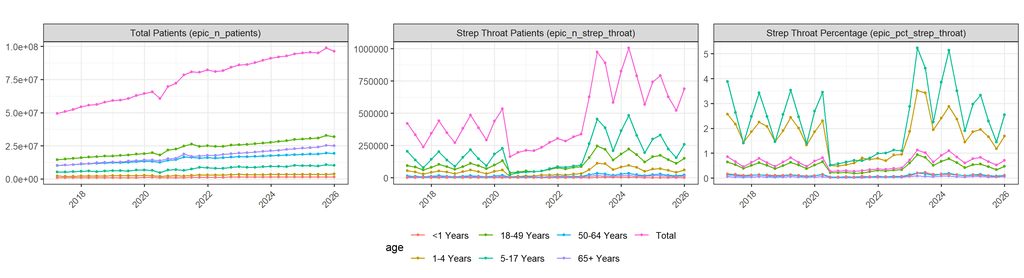

# 5. Choropleth maps

```r
map_ok <- geo_pkgs_ready()

if (!map_ok) {
  cat("_`sf`/`tigris` not available; skipping maps._\n")
} else {
  # choose measures to map
  map_measures <- roles$values
  if (length(map_measures) > params$n_map_measures)
    map_measures <- sort(sample(map_measures, params$n_map_measures))

  # choose up to 4 random years, one random time per year (shared across
  # measures for comparability)
  all_times <- sort(unique(dat$time))
  all_years <- unique(substr(all_times, 1, 4))
  map_years <- sort(sample(all_years, min(4, length(all_years))))
  map_times <- sort(sapply(map_years, function(y) {
    yr_times <- all_times[substr(all_times, 1, 4) == y]
    sample(yr_times, 1)
  }))

  base <- dat %>% filter(time %in% map_times) %>% hold_overall(demo_cols)

  # Precompute each measure's suppression indicator once on `base`, then reuse
  # it for both the state-level and county-level passes below instead of
  # recomputing it once per geography level.
  base[flag_col_name(roles$values)] <- lapply(roles$values, function(v) {
    fl <- measure_flags[[v]]
    if (length(fl)) any_flagged(base, fl) else rep(FALSE, nrow(base))
  })

  has_ggnewscale <- requireNamespace("ggnewscale", quietly = TRUE)
  has_ggpattern  <- requireNamespace("ggpattern",  quietly = TRUE)
  FLAG_FILL    <- c("Suppressed" = "white", "Not available" = "grey75")
  # Suppressed cells also get a diagonal hatch so white doesn't read as a high
  # viridis value.
  FLAG_PATTERN <- c("Suppressed" = "stripe", "Not available" = "none")
  # Flagged cells get a grey border so white (suppressed) cells stay visible
  # against the white page background.
  FLAG_BORDER <- "grey50"

  # For one measure, build a geometry x year grid and draw a 2x2 (year) facet.
  draw_maps <- function(geoms, df, level_label) {
    # The (geography x time) grid is identical for every measure; build it
    # once instead of re-expanding it inside the loop below.
    grid0 <- expand.grid(geography = geoms$geography, time = map_times,
                         stringsAsFactors = FALSE)

    for (m in map_measures) {
      sub <- df %>%
        transmute(geography, time, value = .data[[m]], supp = .data[[flag_col_name(m)]])
      if (all(is.na(sub$value)) && !any(sub$supp, na.rm = TRUE)) next

      md <- grid0 %>%
        left_join(sub, by = c("geography", "time")) %>%
        mutate(flag_label = case_when(
          coalesce(supp, FALSE) ~ "Suppressed",
          is.na(value)          ~ "Not available",
          TRUE                  ~ NA_character_
        )) %>%
        left_join(geoms, by = "geography") %>%
        sf::st_as_sf() %>%
        mutate(year = factor(substr(time, 1, 4),
                             levels = substr(map_times, 1, 4)))

      md_norm <- md %>% filter(is.na(flag_label))
      md_flag <- md %>% filter(!is.na(flag_label)) %>%
        mutate(flag_label = factor(flag_label, levels = names(FLAG_FILL)))

      # Base layer: viridis value scale (flagged cells excluded -> drawn below).
      p <- ggplot() +
        geom_sf(data = md_norm, aes(fill = value),
                color = "white", linewidth = 0.08) +
        scale_fill_viridis_c(option = "viridis", trans = "sqrt",
                             na.value = "grey85", labels = label_number(),
                             name = "value")

      # Overlay layer: suppressed / not-available, with its own scale.
      if (nrow(md_flag) > 0 && has_ggnewscale && has_ggpattern) {
        p <- p + ggnewscale::new_scale_fill() +
          ggpattern::geom_sf_pattern(
            data = md_flag, aes(fill = flag_label, pattern = flag_label),
            pattern_fill = "grey20", pattern_colour = NA,
            pattern_density = 0.3, pattern_spacing = 0.018, pattern_angle = 45,
            colour = FLAG_BORDER, linewidth = 0.08) +
          scale_fill_manual(values = FLAG_FILL, name = NULL, drop = TRUE) +
          ggpattern::scale_pattern_manual(values = FLAG_PATTERN, name = NULL, drop = TRUE)
      } else if (nrow(md_flag) > 0 && has_ggnewscale) {
        p <- p + ggnewscale::new_scale_fill() +
          geom_sf(data = md_flag, aes(fill = flag_label),
                  color = FLAG_BORDER, linewidth = 0.08) +
          scale_fill_manual(values = FLAG_FILL, name = NULL, drop = TRUE)
      } else if (nrow(md_flag) > 0) {
        p <- p +
          geom_sf(data = md_flag %>% filter(flag_label == "Not available"),
                  fill = FLAG_FILL[["Not available"]], color = FLAG_BORDER, linewidth = 0.08) +
          geom_sf(data = md_flag %>% filter(flag_label == "Suppressed"),
                  fill = FLAG_FILL[["Suppressed"]], color = FLAG_BORDER, linewidth = 0.08)
      }

      cap <- if (nrow(md_flag) > 0 && !has_ggnewscale)
        "White (hatched) = suppressed; grey = not available for this geography (install 'ggnewscale'/'ggpattern' for a legend)." else NULL

      p <- p +
        facet_wrap(~year, ncol = 2) +
        coord_sf(crs = 5070, datum = NA) +
        labs(title = measure_label(m), caption = cap) +
        theme_void(base_size = 11) +
        theme(plot.title = element_text(face = "bold", hjust = 0.5, size = 12),
              plot.caption = element_text(hjust = 0.5, color = "grey40", size = 8),
              strip.text = element_text(face = "bold", size = 11),
              legend.position = "right")
      print(p)
    }
  }

  # ---- state maps ----
  state_df <- base %>% filter(nchar(geography) == 2, geography != "00")
  if (nrow(state_df) > 0) {
    cat(sprintf("## State maps (%d measures; years %s)\n\n",
                length(map_measures), paste(substr(map_times, 1, 4), collapse = ", ")))
    states_sf <- get_geo_sf("state")
    if (is.null(states_sf)) cat("_Could not fetch state geometry._\n")
    if (!is.null(states_sf)) draw_maps(states_sf, state_df, "state")
  }

  # ---- county maps ----
  county_df <- base %>% filter(nchar(geography) == 5)
  if (nrow(county_df) > 0) {
    cat(sprintf("\n\n## County maps (%d measures; years %s)\n\n",
                length(map_measures), paste(substr(map_times, 1, 4), collapse = ", ")))
    counties_sf <- get_geo_sf("county")
    if (is.null(counties_sf)) cat("_Could not fetch county geometry._\n")
    if (!is.null(counties_sf)) draw_maps(counties_sf, county_df, "county")
  }

  if (nrow(state_df) == 0 && nrow(county_df) == 0)
    cat("_No state- or county-level rows; skipping maps._\n")
}
```

## State maps (3 measures; years 2017, 2020, 2023, 2025)

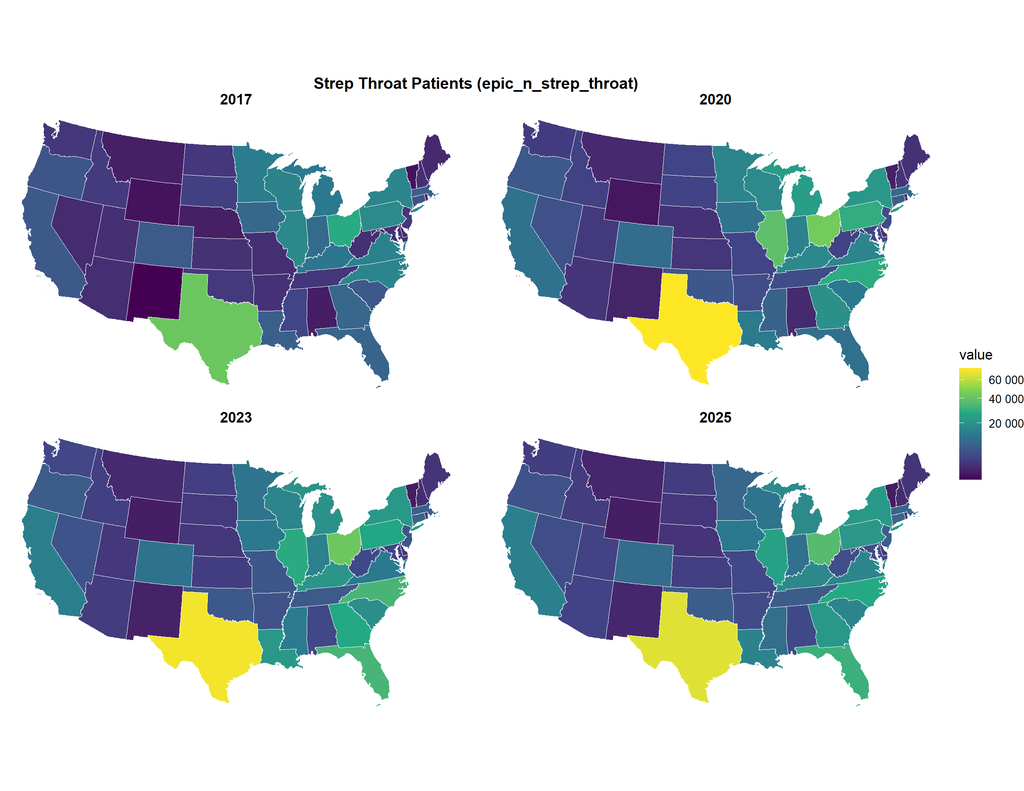

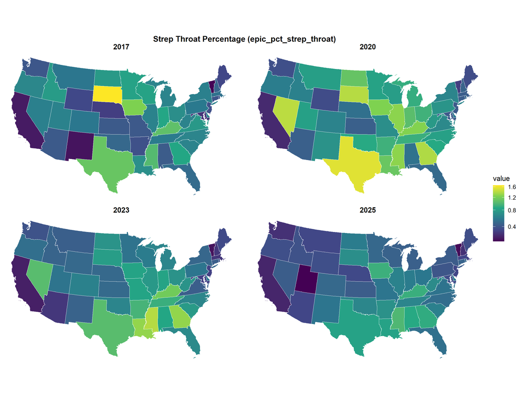

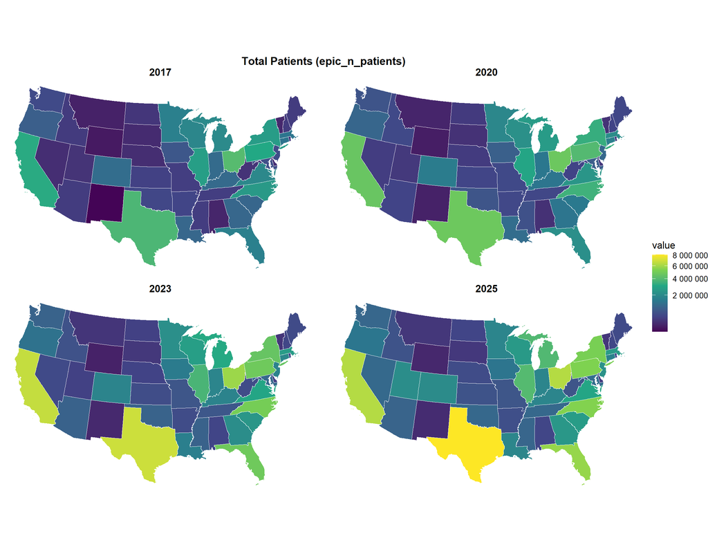

```r
cat("_Maps disabled (`make_maps: false`)._\n")
```

# 6. Comparison with previous version

Map ccompares the change between versions (current minus previous) at the most recent time period the two files have in common. Time series is national data.

```r
if (is.null(old)) {
  cat("_No previous version available (no `old_data_file` supplied and none found via git), skipping trend comparison._\n")
} else {
  shared_vals <- intersect(roles$values, old_roles$values)
  if (length(shared_vals) == 0) {
    cat("_No value measures shared between the current and previous file, skipping._\n")
  } else {
    cat(sprintf("Overlaying **%d** shared measure(s) at the national level: current file vs %s.\n\n",
                length(shared_vals), old_label))

    new_nat <- hold_overall(dat %>% filter(geography == "00"), roles$demo)
    old_nat <- hold_overall(old %>% filter(geography == "00"), old_roles$demo)

    combined <- bind_rows(
      lapply(shared_vals, function(v) {
        bind_rows(
          new_nat %>% transmute(time = as.Date(time), measure = v,
                                value = .data[[v]], source = "current"),
          old_nat %>% transmute(time = as.Date(time), measure = v,
                                value = .data[[v]], source = "previous")
        )
      })
    ) %>% filter(!is.na(value))

    p <- ggplot(combined, aes(time, value, color = source, group = source)) +
      geom_line(linewidth = 0.6) + geom_point(size = 0.8) +
      facet_wrap(~measure, scales = "free_y", ncol = FACET_NCOL,
                 labeller = labeller(measure = measure_label)) +
      labs(title = NULL, x = NULL, y = NULL, color = NULL) +
      theme_bw(base_size = 11) +
      theme(legend.position = "bottom",
            axis.text.x = element_text(angle = 45, hjust = 1))
    print(p)

    only_new <- setdiff(roles$values, old_roles$values)
    only_old <- setdiff(old_roles$values, roles$values)
    if (length(only_new))
      cat(sprintf("\n\n**Measures only in the current file:** %s\n", paste(only_new, collapse=", ")))
    if (length(only_old))
      cat(sprintf("\n\n**Measures only in the previous file:** %s\n", paste(only_old, collapse=", ")))
  }
}
```

Overlaying **3** shared measure(s) at the national level: current file vs its previous **git** version: 681eb504 (2026-08-04) — standardize cosmos_gas to PopHIVE wide format.

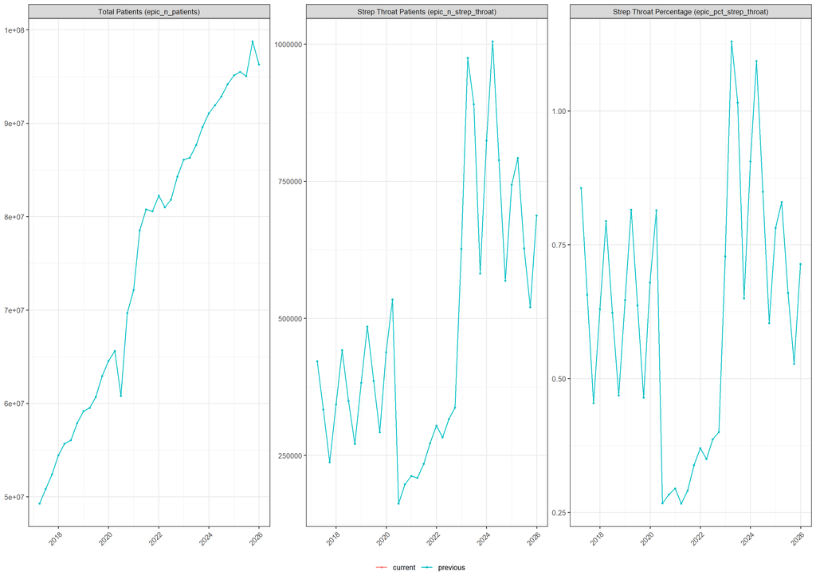

## Change map: current vs previous

```r
if (is.null(old)) {
  cat("_No previous version available, skipping change map._\n")
} else {
  diff_map_ok <- geo_pkgs_ready()
  if (!diff_map_ok) {
    cat("_`sf`/`tigris` not available; skipping change map._\n")
  } else {
    is_pct_type <- function(v) measure_type_of(v, measure_info) %in% "percent" ||
      (is.na(measure_type_of(v, measure_info)) && all(dat[[v]] >= 0 & dat[[v]] <= 100, na.rm = TRUE))
    pct_shared <- intersect(roles$values, old_roles$values)
    pct_shared <- pct_shared[vapply(pct_shared, is_pct_type, logical(1))]

    shared_time <- intersect(dat$time, old$time)

    if (length(pct_shared) == 0) {
      cat("_No shared percent-type measures between the current and previous file; skipping change map._\n")
    } else if (length(shared_time) == 0) {
      cat("_No time period is shared between the current and previous file; skipping change map._\n")
    } else {
      latest_time <- max(shared_time)
      cat(sprintf("Change in **%s** (current minus previous) at the most recent period shared by both files: **%s**.\n\n",
                  paste(pct_shared, collapse = ", "), latest_time))

      new_slice <- hold_overall(dat %>% filter(time == latest_time), roles$demo)
      old_slice <- hold_overall(old %>% filter(time == latest_time), old_roles$demo)

      draw_diff_map <- function(geoms, level_label) {
        keep <- if (level_label == "state") \(g) nchar(g) == 2 & g != "00" else \(g) nchar(g) == 5
        new_g <- new_slice %>% filter(keep(geography))
        old_g <- old_slice %>% filter(keep(geography))
        if (nrow(new_g) == 0 || nrow(old_g) == 0) return(invisible(NULL))

        diffs <- bind_rows(lapply(pct_shared, function(v) {
          full_join(new_g %>% transmute(geography, new_val = .data[[v]]),
                    old_g %>% transmute(geography, old_val = .data[[v]]),
                    by = "geography") %>%
            transmute(geography, measure = v, diff = new_val - old_val)
        }))
        if (all(is.na(diffs$diff))) return(invisible(NULL))

        md <- geoms %>% left_join(diffs, by = "geography") %>% sf::st_as_sf()

        p <- ggplot(md) +
          geom_sf(aes(fill = diff), color = "white", linewidth = 0.08) +
          scale_fill_gradient2(low = "#2166ac", mid = "grey95", high = "#b2182b",
                               midpoint = 0, na.value = "grey85", name = "pct-point\nchange") +
          facet_wrap(~measure, labeller = labeller(measure = measure_label)) +
          coord_sf(crs = 5070, datum = NA) +
          labs(title = sprintf("%s: change vs previous version (%s)",
                               tools::toTitleCase(level_label), latest_time)) +
          theme_void(base_size = 11) +
          theme(plot.title = element_text(face = "bold", hjust = 0.5, size = 12),
                strip.text = element_text(face = "bold", size = 11),
                legend.position = "right")
        print(p)
      }

      states_sf <- get_geo_sf("state")
      if (!is.null(states_sf)) draw_diff_map(states_sf, "state")
      counties_sf <- get_geo_sf("county")
      if (!is.null(counties_sf)) draw_diff_map(counties_sf, "county")
      if (is.null(states_sf) && is.null(counties_sf))
        cat("_Could not fetch state or county geometry._\n")
    }
  }
}
```

Change in **epic_pct_strep_throat** (current minus previous) at the most recent period shared by both files: **2025-12-31**.

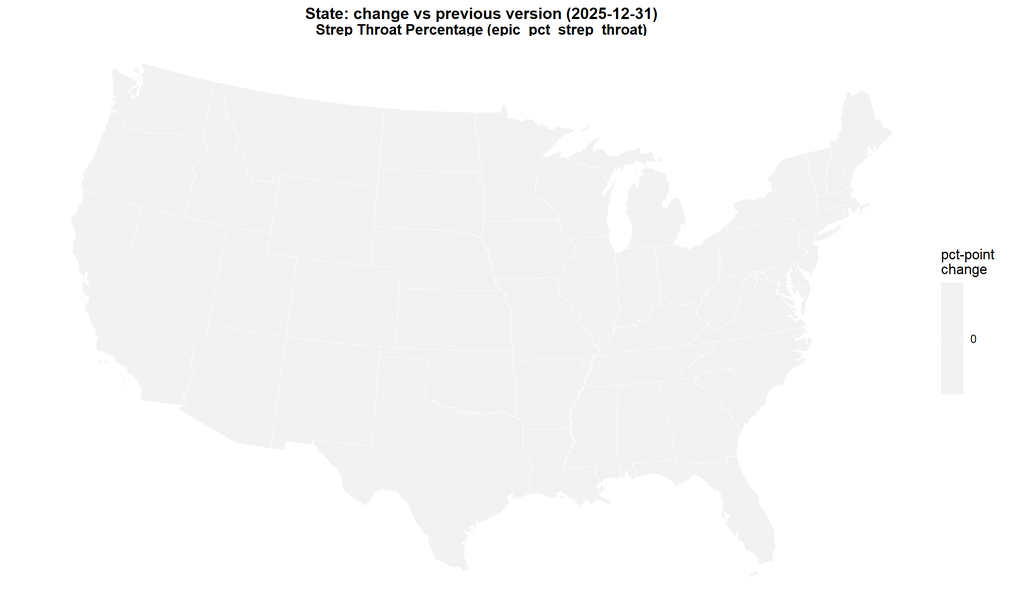

````r
cat("<details><summary>Session info</summary>\n\n```\n")
````

**Session info**

[output not shown]

R version 4.6.1 (2026-06-24 ucrt) Platform: x86_64-w64-mingw32/x64 Running under: Windows 11 x64 (build 26200)

Matrix products: default LAPACK version 3.12.1

locale: [1] LC_COLLATE=English_United States.utf8 [2] LC_CTYPE=English_United States.utf8  
[3] LC_MONETARY=English_United States.utf8 [4] LC_NUMERIC=C  
[5] LC_TIME=English_United States.utf8

time zone: America/New_York tzcode source: internal

attached base packages: [1] stats graphics grDevices utils datasets methods base

other attached packages: [1] tigris_2.2.1 sf_1.1-1 jsonlite_2.0.0 knitr_1.51 scales_1.4.0  
[6] ggplot2_4.0.3 vroom_1.7.1 tidyr_1.3.2 dplyr_1.2.1

loaded via a namespace (and not attached): [1] rappdirs_0.3.4 sass_0.4.10 generics_0.1.4 class_7.3-23  
[5] KernSmooth_2.23-26 stringi_1.8.7 digest_0.6.39 magrittr_2.0.5  
[9] evaluate_1.0.5 grid_4.6.1 RColorBrewer_1.1-3 fastmap_1.2.0  
[13] ggnewscale_0.5.2 e1071_1.7-17 DBI_1.3.0 httr_1.4.8  
[17] purrr_1.2.2 viridisLite_0.4.3 jquerylib_0.1.4 cli_3.6.6  
[21] ggpattern_1.3.1 rlang_1.2.0 crayon_1.5.3 units_1.0-1  
[25] bit64_4.8.2 withr_3.0.3 cachem_1.1.0 yaml_2.3.12  
[29] otel_0.2.0 tools_4.6.1 parallel_4.6.1 uuid_1.2-2  
[33] tzdb_0.5.0 pandoc_0.2.0 vctrs_0.7.3 R6_2.6.1  
[37] proxy_0.4-29 lifecycle_1.0.5 classInt_0.4-11 stringr_1.6.0  
[41] fs_2.1.0 bit_4.6.0 pkgconfig_2.0.3 pillar_1.11.1  
[45] bslib_0.11.0 gtable_0.3.6 Rcpp_1.1.1-1.1 glue_1.8.1  
[49] xfun_0.59 tibble_3.3.1 tidyselect_1.2.1 farver_2.1.2  
[53] htmltools_0.5.9 rmarkdown_2.31 labeling_0.4.3 compiler_4.6.1  
[57] S7_0.2.2

````r
cat("\n```\n</details>\n")
````

[output not shown]